# Лабораторна робота № 3. Основи вибіркового методу

Author

Озівський Владислав

Published

5 грудня 2025 р.

## 1. Постановка завдання

**Мета:** Засвоїти основи статистичного оцінювання характеристик випадкової величини на основі вибіркового підходу засобами мови програмування R (Сидоренко 2025).

**Індивідуальне завдання (Еталонний варіант):** Випадкова величина $X$ має нормальний закон розподілу: $X \sim N(a, \sigma^2)$ з параметрами:
$$a = 0, \quad \sigma = 1$$

Необхідно: 1. Згенерувати дві вибірки обсягом $n_1 = 100$ та $n_2 = 10000$. 2. Побудувати графіки: гістограму з теоретичною кривою, емпіричну функцію розподілу, boxplot. 3. Обчислити точкові оцінки параметрів (середнє, дисперсія, асиметрія, ексцес). 4. Звести результати у порівняльну таблицю.

## 2. Короткі теоретичні відомості

Вибірковий метод полягає у вивченні властивостей генеральної сукупності за допомогою випадкової вибірки. Основні характеристики:

- **Вибіркове середнє:** $\bar{x} = \frac{1}{n}\sum x_i$ (оцінка $a$).
- **Вибіркова дисперсія (виправлена):** $s^2 = \frac{1}{n-1}\sum (x_i - \bar{x})^2$ (оцінка $\sigma^2$).
- **Асиметрія ($A_s$):** Характеризує скошеність розподілу. Для нормального розподілу $A_s=0$.
- **Ексцес ($E_k$):** Характеризує гостроверхість. Для нормального розподілу $E_k=0$ (у “excess” формі).

## 3. Виконання роботи

### 3.1 Підготовка середовища та функцій

```r
library(knitr)
library(ggplot2)

# Функція для розрахунку асиметрії
calc_skewness <- function(x) {
  n <- length(x)
  m3 <- sum((x - mean(x))^3) / n
  s3 <- sqrt(var(x) * (n-1)/n)^3
  return(m3 / s3)
}

# Функція для розрахунку ексцесу (excess kurtosis, норма = 0)
calc_kurtosis <- function(x) {
  n <- length(x)
  m4 <- sum((x - mean(x))^4) / n
  s4 <- var(x)^2 * ((n-1)/n)^2
  return((m4 / s4) - 3)
}

# Функція для комплексного аналізу вибірки
analyze_sample <- function(x, n_name) {
  # Розрахунок статистик
  m_hat <- mean(x)
  var_hat <- var(x) # Виправлена дисперсія
  sd_hat <- sd(x)
  skew <- calc_skewness(x)
  kurt <- calc_kurtosis(x)

  # Вивід результатів у консоль (для контролю)
  cat(paste0("\n--- Аналіз вибірки ", n_name, " ---\n"))
  cat("Середнє:", round(m_hat, 4), "\n")
  cat("СКВ:", round(sd_hat, 4), "\n")

  # Повертаємо вектор статистик для таблиці
  return(c(m_hat, var_hat, sd_hat, skew, kurt))
}
```

### 3.2 Генерація даних та аналіз для n = 100

```r
set.seed(42) # Для відтворюваності
a_theor <- 0
sigma_theor <- 1

# Генерація
n1 <- 100
sample_100 <- rnorm(n1, mean = a_theor, sd = sigma_theor)

# Аналіз статистик
stats_100 <- analyze_sample(sample_100, "n=100")
```

```
--- Аналіз вибірки n=100 ---
Середнє: 0.0325
СКВ: 1.0414
```

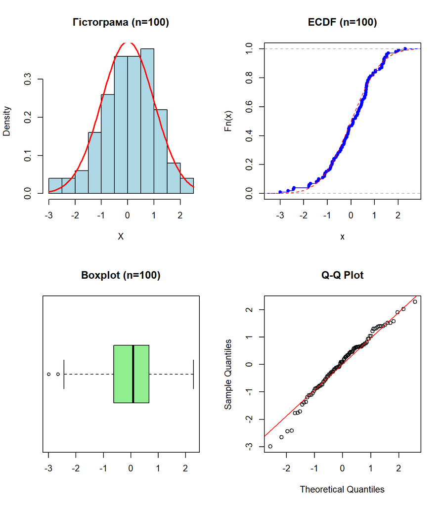

```r
# Візуалізація (Комплексний графік)
par(mfrow = c(2, 2)) # Сітка 2х2

# 1. Гістограма + Теоретична крива
hist(sample_100, freq = FALSE, main = "Гістограма (n=100)", col = "lightblue", xlab = "X")
curve(dnorm(x, a_theor, sigma_theor), add = TRUE, col = "red", lwd = 2)

# 2. Емпірична функція розподілу
plot(ecdf(sample_100), main = "ECDF (n=100)", col = "blue", verticals = TRUE)
curve(pnorm(x, a_theor, sigma_theor), add = TRUE, col = "red", lty = 2)

# 3. Boxplot
boxplot(sample_100, horizontal = TRUE, main = "Boxplot (n=100)", col = "lightgreen")

# 4. Q-Q Plot
qqnorm(sample_100, main = "Q-Q Plot"); qqline(sample_100, col = "red")
```

```r
par(mfrow = c(1, 1)) # Скидання параметрів графіки
```

### 3.3 Генерація даних та аналіз для n = 10000

```r
# Генерація
n2 <- 10000
sample_10k <- rnorm(n2, mean = a_theor, sd = sigma_theor)

# Аналіз статистик
stats_10k <- analyze_sample(sample_10k, "n=10000")
```

```
--- Аналіз вибірки n=10000 ---
Середнє: -0.0097
СКВ: 1.0055
```

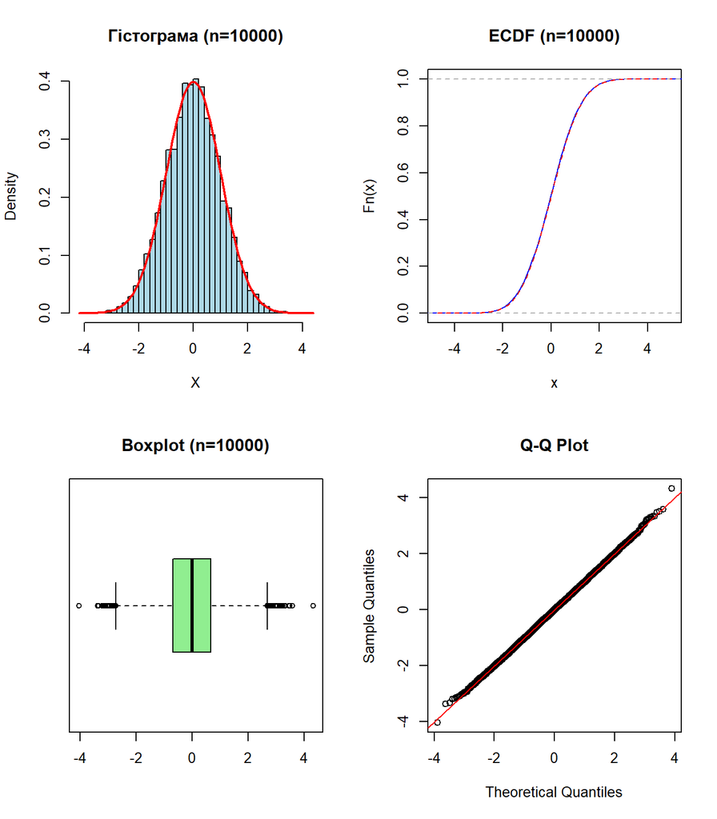

```r
# Візуалізація
par(mfrow = c(2, 2))

# 1. Гістограма
hist(sample_10k, freq = FALSE, main = "Гістограма (n=10000)", col = "lightblue", xlab = "X", breaks = 50)
curve(dnorm(x, a_theor, sigma_theor), add = TRUE, col = "red", lwd = 2)

# 2. ECDF
plot(ecdf(sample_10k), main = "ECDF (n=10000)", col = "blue", verticals = TRUE, pch = NA)
curve(pnorm(x, a_theor, sigma_theor), add = TRUE, col = "red", lty = 2)

# 3. Boxplot
boxplot(sample_10k, horizontal = TRUE, main = "Boxplot (n=10000)", col = "lightgreen")

# 4. Q-Q Plot
qqnorm(sample_10k, main = "Q-Q Plot"); qqline(sample_10k, col = "red")
```

```r
par(mfrow = c(1, 1))
```

### 3.4 Зведена таблиця результатів

Порівняємо отримані вибіркові оцінки з теоретичними значеннями.

```r
# Створення таблиці
results_table <- data.frame(
  Parameter = c("Середнє (a)", "Дисперсія (s^2)", "СКВ (s)", "Асиметрія (As)", "Ексцес (Ek)"),
  Theoretical = c(a_theor, sigma_theor^2, sigma_theor, 0, 0),
  Sample_100 = round(stats_100, 4),
  Sample_10000 = round(stats_10k, 4)
)

# Розрахунок похибок
results_table$Error_100 = abs(results_table$Sample_100 - results_table$Theoretical)
results_table$Error_10000 = abs(results_table$Sample_10000 - results_table$Theoretical)

kable(results_table, caption = "Порівняння теоретичних та емпіричних характеристик")
```

Порівняння теоретичних та емпіричних характеристик

| Parameter | Theoretical | Sample_100 | Sample_10000 | Error_100 | Error_10000 |
| --- | --- | --- | --- | --- | --- |
| Середнє (a) | 0 | 0.0325 | -0.0097 | 0.0325 | 0.0097 |
| Дисперсія (s^2) | 1 | 1.0844 | 1.0111 | 0.0844 | 0.0111 |
| СКВ (s) | 1 | 1.0414 | 1.0055 | 0.0414 | 0.0055 |
| Асиметрія (As) | 0 | -0.4761 | 0.0116 | 0.4761 | 0.0116 |
| Ексцес (Ek) | 0 | 0.2092 | -0.0082 | 0.2092 | 0.0082 |

## 4. Висновки

У ході лабораторної роботи було досліджено властивості вибіркового методу на прикладі нормального розподілу $N(0, 1)$.

## Перелік посилань

Сидоренко, В. М. 2025. *Лабораторна робота № 3. Основи вибіркового методу*.